# Comprehensive Guide to Posit Cloud for CLTR6501

CLTR6501 Course Staff

# Introduction to Posit Cloud for Biostatistics

Welcome to CLTR6501! This comprehensive guide will introduce you to Posit Cloud (formerly RStudio Cloud), the platform we’ll be using for our R programming and biostatistical analysis tasks throughout the course.

## What is Posit Cloud?

Posit Cloud is a cloud-based version of RStudio, a powerful integrated development environment (IDE) for R. It allows you to write, run, and share R code directly in your web browser, providing a consistent and accessible environment for statistical computing and data analysis.

## Why Posit Cloud for CLTR6501?

1. **Accessibility**: Access your R projects from any device with an internet connection.
2. **Consistency**: Everyone uses the same R version and package setup, eliminating “works on my machine” issues.
3. **Collaboration**: Easily share projects with instructors and peers for feedback and group work.
4. **Pre-configured Environment**: Course-specific packages and datasets can be pre-loaded.
5. **Cloud Computing**: Leverage cloud resources for computationally intensive biostatistical analyses.

# Getting Started with Posit Cloud

## Step 1: Sign Up and Access

1. Navigate to https://posit.cloud/
2. Click “Get Started” and choose “Sign Up”
3. Use your university email to create an account
4. Verify your email if required

## Step 2: Join the CLTR6501 Workspace

1. After logging in, you’ll see your Posit Cloud dashboard
2. Look for an email or announcement with the CLTR6501 workspace link
3. Click the link and select “Join Space”

## Step 3: Navigating the Posit Cloud Interface

The Posit Cloud interface is designed for intuitive navigation. Here’s a text-based description of the key elements:

- **Top Navigation Bar**:
  - Left: Posit Cloud logo and workspace name
  - Center: New Project, Projects, Spaces, and Learn options
  - Right: Account settings and notifications
- **Main Dashboard**:
  - Projects list: Shows your recent and pinned projects
  - Left Sidebar: Quick access to different spaces and account settings

# Working with Projects in Posit Cloud

## Creating a New Project

1. Click “New Project” in the top navigation bar
2. Choose from options:
   - “New RStudio Project”: Blank R project
   - “New Project from Git Repo”: Clone an existing Git repository
   - “Copy a Project”: Duplicate an existing project

## The RStudio IDE in Posit Cloud

The RStudio interface in Posit Cloud is divided into four main panes:

1. **Source Editor** (Top-Left):
   - Write and edit R scripts, R Markdown documents, and other files
   - Syntax highlighting and auto-completion for efficient coding
2. **Console** (Bottom-Left):
   - Run R commands interactively
   - View output from executed code
3. **Environment/History** (Top-Right):
   - Environment: View and manage your data objects and variables
   - History: See a list of previously executed commands
4. **Files/Plots/Packages/Help/Viewer** (Bottom-Right):
   - Files: Manage project files and directories
   - Plots: View generated plots and graphics
   - Packages: Install and load R packages
   - Help: Access R documentation
   - Viewer: Display web content and HTML widgets

## Running R Code

Let’s start with some basic R operations relevant to biostatistics:

```r
# Basic statistical operations
data <- c(23, 25, 28, 29, 30, 32, 35, 37, 40)
mean_value <- mean(data)
median_value <- median(data)
sd_value <- sd(data)

cat("Mean:", mean_value, "\n")
```

```
## Mean: 31
```

```r
cat("Median:", median_value, "\n")
```

```
## Median: 30
```

```r
cat("Standard Deviation:", sd_value, "\n")
```

```
## Standard Deviation: 5.567764
```

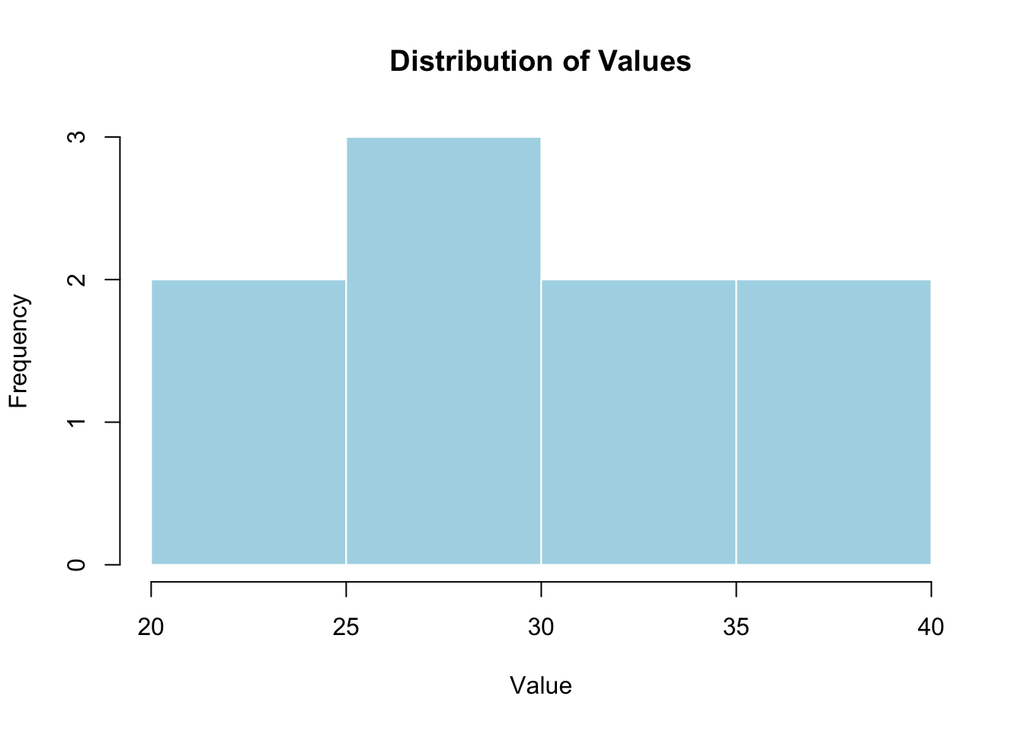

```r
# Create a simple histogram
hist(data, main = "Distribution of Values", xlab = "Value", col = "lightblue", border = "white")
```

To run code: 1. Type or paste code into the Source Editor 2. Select the code you want to run 3. Click “Run” or press Ctrl+Enter (Cmd+Enter on Mac)

## Installing and Loading Packages

Posit Cloud comes with many packages pre-installed, but you may need to install additional ones:

```r
# Install a package
install.packages("ggplot2")

# Load a package
library(ggplot2)

# Check installed packages
installed.packages()[, c("Package", "Version")]
```

## Working with Data in Posit Cloud

### Importing Data

Posit Cloud supports various data import methods:

```r
# CSV file (replace with actual file path)
data <- read.csv("your_data.csv")

# Excel file (requires readxl package)
library(readxl)
excel_data <- read_excel("your_data.xlsx")

# From URL
url_data <- read.csv("https://example.com/data.csv")
```

### Basic Data Manipulation

Here’s an example using the built-in `mtcars` dataset:

```r
# Load dplyr for data manipulation
library(dplyr)

# Basic operations on mtcars dataset
mtcars_summary <- mtcars %>%
  group_by(cyl) %>%
  summarize(
    mean_mpg = mean(mpg),
    sd_mpg = sd(mpg),
    count = n()
  )

print(mtcars_summary)
```

```
## # A tibble: 3 × 4
##     cyl mean_mpg sd_mpg count
##   <dbl>    <dbl>  <dbl> <int>
## 1     4     26.7   4.51    11
## 2     6     19.7   1.45     7
## 3     8     15.1   2.56    14
```

[figure not shown]

```r
# Visualization with ggplot2
library(ggplot2)

ggplot(mtcars, aes(x = factor(cyl), y = mpg)) +
  geom_boxplot(fill = "lightblue") +
  labs(title = "MPG Distribution by Number of Cylinders",
       x = "Number of Cylinders",
       y = "Miles Per Gallon")
```

## Saving and Sharing Your Work

### Saving Projects

- Posit Cloud autosaves your work frequently
- Manually save: File > Save or Ctrl+S (Cmd+S on Mac)

### Sharing Projects

1. Click “Share” in the top-right corner of your project
2. Set permissions (View, Edit, or None)
3. Copy the generated link to share

# Advanced Features for Biostatistics

## Using R Markdown for Reports

R Markdown is crucial for creating reproducible reports in biostatistics. Here’s a basic example:

```r
---
title: "Basic Biostatistics Report"
output: html_document
---

## Data Analysis

We analyze the `mtcars` dataset:
```

```r
summary(mtcars)
```

```
##       mpg             cyl             disp             hp
##  Min.   :10.40   Min.   :4.000   Min.   : 71.1   Min.   : 52.0
##  1st Qu.:15.43   1st Qu.:4.000   1st Qu.:120.8   1st Qu.: 96.5
##  Median :19.20   Median :6.000   Median :196.3   Median :123.0
##  Mean   :20.09   Mean   :6.188   Mean   :230.7   Mean   :146.7
##  3rd Qu.:22.80   3rd Qu.:8.000   3rd Qu.:326.0   3rd Qu.:180.0
##  Max.   :33.90   Max.   :8.000   Max.   :472.0   Max.   :335.0
##       drat             wt             qsec             vs
##  Min.   :2.760   Min.   :1.513   Min.   :14.50   Min.   :0.0000
##  1st Qu.:3.080   1st Qu.:2.581   1st Qu.:16.89   1st Qu.:0.0000
##  Median :3.695   Median :3.325   Median :17.71   Median :0.0000
##  Mean   :3.597   Mean   :3.217   Mean   :17.85   Mean   :0.4375
##  3rd Qu.:3.920   3rd Qu.:3.610   3rd Qu.:18.90   3rd Qu.:1.0000
##  Max.   :4.930   Max.   :5.424   Max.   :22.90   Max.   :1.0000
##        am              gear            carb
##  Min.   :0.0000   Min.   :3.000   Min.   :1.000
##  1st Qu.:0.0000   1st Qu.:3.000   1st Qu.:2.000
##  Median :0.0000   Median :4.000   Median :2.000
##  Mean   :0.4062   Mean   :3.688   Mean   :2.812
##  3rd Qu.:1.0000   3rd Qu.:4.000   3rd Qu.:4.000
##  Max.   :1.0000   Max.   :5.000   Max.   :8.000
```

```r
# Correlation between mpg and weight
cor.test(mtcars$mpg, mtcars$wt)
```

```
##
##  Pearson's product-moment correlation
##
## data:  mtcars$mpg and mtcars$wt
## t = -9.559, df = 30, p-value = 1.294e-10
## alternative hypothesis: true correlation is not equal to 0
## 95 percent confidence interval:
##  -0.9338264 -0.7440872
## sample estimates:
##        cor
## -0.8676594
```

## Visualization

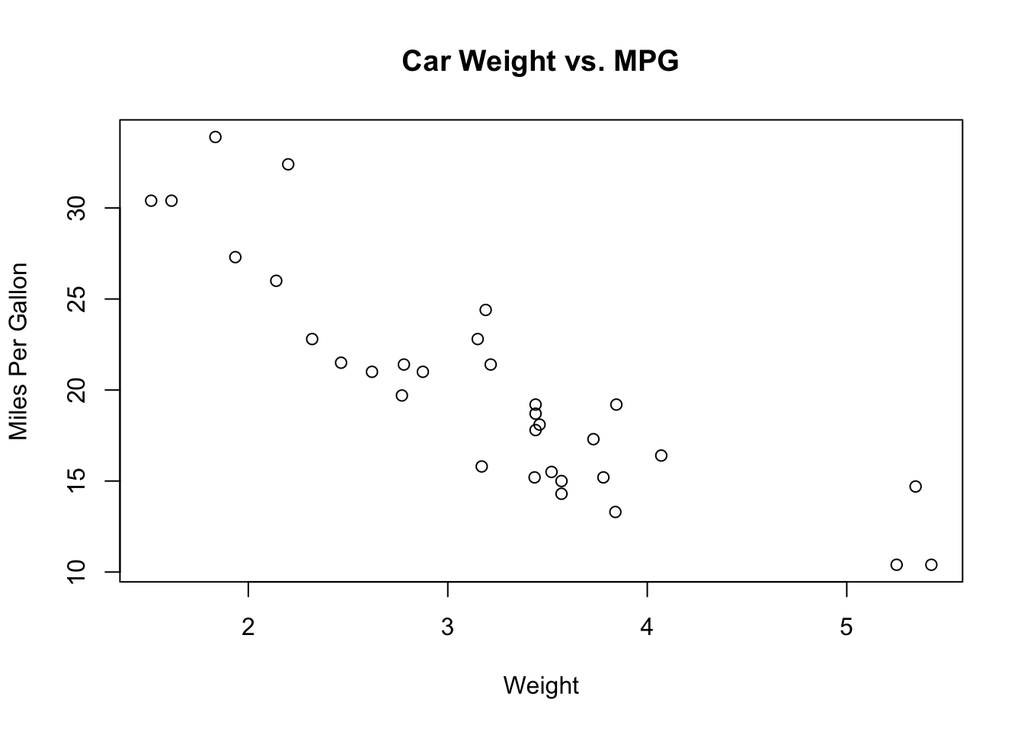

```r
plot(mtcars$wt, mtcars$mpg,
     main="Car Weight vs. MPG",
     xlab="Weight", ylab="Miles Per Gallon")
```

## Version Control with Git

Posit Cloud supports Git for version control:

1. In your project, go to Tools > Version Control > Project Setup
2. Choose “Git” as the version control system
3. Use the Git pane (top-right) to stage, commit, and push changes

## Computational Performance

For computationally intensive tasks:

1. Increase project resources: Settings > Editor > Resources
2. Use parallel processing packages like `parallel` or `foreach`

# Best Practices for CLTR6501

1. **Organize Your Work**: Use clear file and folder structures
2. **Comment Your Code**: Write explanatory comments for complex operations
3. **Use R Markdown**: Combine code, output, and explanations in one document
4. **Regular Commits**: If using Git, commit changes frequently with meaningful messages
5. **Collaborate Responsibly**: When sharing projects, be mindful of data privacy and code attribution

# Troubleshooting and Support

## Common Issues and Solutions

1. **Slow Performance**:
   - Close unused projects and browser tabs
   - Clear your browser cache
   - Upgrade your Posit Cloud plan if needed
2. **Package Installation Failures**:
   - Check your internet connection
   - Ensure you have the latest R version: `R.Version()`
   - Try installing from the Packages pane instead of the console
3. **Project Won’t Load**:
   - Try accessing the project in a different browser
   - Contact Posit Cloud support if persistent

## Getting Help

- **In-Platform Help**: Use the Help pane in RStudio
- **Course Forum**: Post questions on our CLTR6501 discussion board
- **Office Hours**: Attend scheduled help sessions
- **Posit Cloud Documentation**: Visit [Posit Cloud Learn](https://posit.cloud/learn/guide)

# Conclusion

Mastering Posit Cloud will significantly enhance your learning experience in CLTR6501. It provides a robust platform for applying biostatistical methods and collaborating with peers. As you progress through the course, you’ll discover how Posit Cloud can streamline your workflow and allow you to focus on statistical concepts and data analysis.

Remember, the key to success is practice and exploration. Don’t hesitate to experiment with different features and ask questions when you encounter challenges.

Good luck with your biostatistical journey in CLTR6501!

| Skill | Importance |
| --- | --- |
| R Basics | Fundamental |
| Data Import | Essential |
| Statistical Analysis | Core |
| Data Visualization | High |
| R Markdown | Critical |
| Version Control | Advanced |

This guide covers the essential aspects of using Posit Cloud for your biostatistics course. As you progress, refer back to this document and explore the additional resources provided. Happy analyzing!